# USL project - Fuel consumption

```python
final_USL_data.head()
```

[output not shown]

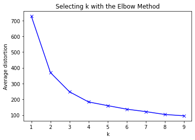

```python
#Finding optimal no. of clusters
from scipy.spatial.distance import cdist
clusters=range(1,10)
meanDistortions=[]

for k in clusters:
    model=KMeans(n_clusters=k)
    model.fit(final_USL_data)
    prediction=model.predict(final_USL_data)
    meanDistortions.append(sum(np.min(cdist(final_USL_data, model.cluster_centers_, 'euclidean'), axis=1)) / final_USL_data.shape[0])


plt.plot(clusters, meanDistortions, 'bx-')
plt.xlabel('k')
plt.ylabel('Average distortion')
plt.title('Selecting k with the Elbow Method')
```

```python
# possible elbow points at 3 and 4
```

```python
# Let us first start with K = 3
final_model=KMeans(3)
final_model.fit(final_USL_data)
prediction=final_model.predict(final_USL_data)

#Append the prediction
final_USL_data["GROUP"] = prediction
final_USL_data["GROUP"] = prediction
print("Groups Assigned : \n")
final_USL_data.head()
```

```
Groups Assigned :
```

|  | MPG | Cylinder | Displacement | Horsepower | Weight | Accleration | Origin | 0 | 1 | 2 | GROUP |
| --- | --- | --- | --- | --- | --- | --- | --- | --- | --- | --- | --- |
| 0 | 18.0 | 8 | 307.0 | 130 | 3504.0 | 12.0 | 1 | 1.0 | 0.0 | 0.0 | 1 |
| 1 | 15.0 | 8 | 350.0 | 165 | 3693.0 | 11.5 | 1 | 1.0 | 0.0 | 0.0 | 2 |
| 2 | 18.0 | 8 | 318.0 | 150 | 3436.0 | 11.0 | 1 | 1.0 | 0.0 | 0.0 | 1 |
| 3 | 16.0 | 8 | 304.0 | 150 | 3433.0 | 12.0 | 1 | 1.0 | 0.0 | 0.0 | 1 |
| 4 | 17.0 | 8 | 302.0 | 140 | 3449.0 | 10.5 | 1 | 1.0 | 0.0 | 0.0 | 1 |

```python
USL_clust = final_USL_data.groupby(['GROUP'])
USL_clust.mean()
```

| GROUP | MPG | Cylinder | Displacement | Horsepower | Weight | Accleration | Origin | 0 | 1 | 2 |
| --- | --- | --- | --- | --- | --- | --- | --- | --- | --- | --- |
| 0 | 29.751099 | 4.038462 | 106.953297 | 77.478022 | 2217.670330 | 16.358791 | 2.049451 | 0.335165 | 0.280220 | 0.384615 |
| 1 | 20.848413 | 5.777778 | 210.674603 | 105.238095 | 3153.523810 | 15.929365 | 1.285714 | 0.785714 | 0.142857 | 0.071429 |
| 2 | 14.635556 | 7.866667 | 344.144444 | 157.811111 | 4236.322222 | 13.463333 | 1.011111 | 0.988889 | 0.011111 | 0.000000 |

```
array([[<AxesSubplot:title={'center':'0'}, xlabel='[GROUP]'>,
        <AxesSubplot:title={'center':'1'}, xlabel='[GROUP]'>,
        <AxesSubplot:title={'center':'2'}, xlabel='[GROUP]'>,
        <AxesSubplot:title={'center':'Accleration'}, xlabel='[GROUP]'>,
        <AxesSubplot:title={'center':'Cylinder'}, xlabel='[GROUP]'>],
       [<AxesSubplot:title={'center':'Displacement'}, xlabel='[GROUP]'>,
        <AxesSubplot:title={'center':'Horsepower'}, xlabel='[GROUP]'>,
        <AxesSubplot:title={'center':'MPG'}, xlabel='[GROUP]'>,
        <AxesSubplot:title={'center':'Origin'}, xlabel='[GROUP]'>,
        <AxesSubplot:title={'center':'Weight'}, xlabel='[GROUP]'>],
       [<AxesSubplot:>, <AxesSubplot:>, <AxesSubplot:>, <AxesSubplot:>,
        <AxesSubplot:>],
       [<AxesSubplot:>, <AxesSubplot:>, <AxesSubplot:>, <AxesSubplot:>,
        <AxesSubplot:>],
       [<AxesSubplot:>, <AxesSubplot:>, <AxesSubplot:>, <AxesSubplot:>,
        <AxesSubplot:>]], dtype=object)
```

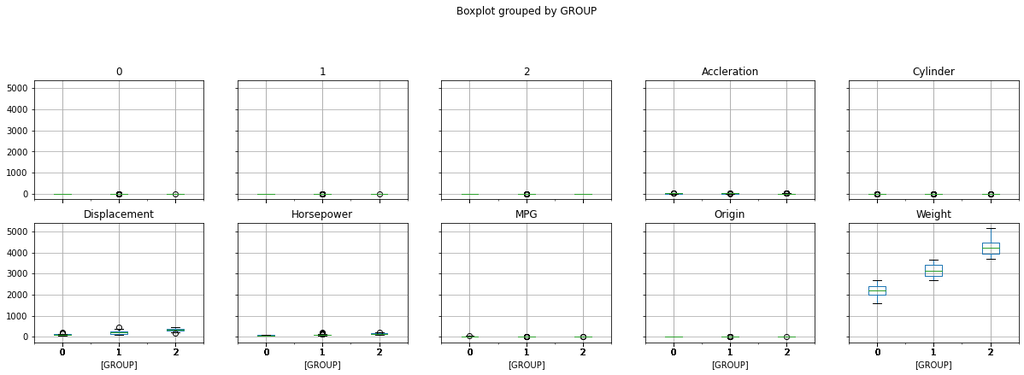

```python
final_USL_data.boxplot(by='GROUP', layout = (5,5),figsize=(20,15))
```

```python
# Let us first start with K = 4
final_model=KMeans(4)
final_model.fit(final_USL_data)
prediction=final_model.predict(final_USL_data)

#Append the prediction
final_USL_data["GROUP"] = prediction
final_USL_data["GROUP"] = prediction
print("Groups Assigned : \n")
final_USL_data.head()
```

```
Groups Assigned :
```

|  | MPG | Cylinder | Displacement | Horsepower | Weight | Accleration | Origin | 0 | 1 | 2 | GROUP |
| --- | --- | --- | --- | --- | --- | --- | --- | --- | --- | --- | --- |
| 0 | 18.0 | 8 | 307.0 | 130 | 3504.0 | 12.0 | 1 | 1.0 | 0.0 | 0.0 | 3 |
| 1 | 15.0 | 8 | 350.0 | 165 | 3693.0 | 11.5 | 1 | 1.0 | 0.0 | 0.0 | 3 |
| 2 | 18.0 | 8 | 318.0 | 150 | 3436.0 | 11.0 | 1 | 1.0 | 0.0 | 0.0 | 3 |
| 3 | 16.0 | 8 | 304.0 | 150 | 3433.0 | 12.0 | 1 | 1.0 | 0.0 | 0.0 | 3 |
| 4 | 17.0 | 8 | 302.0 | 140 | 3449.0 | 10.5 | 1 | 1.0 | 0.0 | 0.0 | 3 |

```
array([[<AxesSubplot:title={'center':'0'}, xlabel='[GROUP]'>,
        <AxesSubplot:title={'center':'1'}, xlabel='[GROUP]'>,
        <AxesSubplot:title={'center':'2'}, xlabel='[GROUP]'>,
        <AxesSubplot:title={'center':'Accleration'}, xlabel='[GROUP]'>,
        <AxesSubplot:title={'center':'Cylinder'}, xlabel='[GROUP]'>],
       [<AxesSubplot:title={'center':'Displacement'}, xlabel='[GROUP]'>,
        <AxesSubplot:title={'center':'Horsepower'}, xlabel='[GROUP]'>,
        <AxesSubplot:title={'center':'MPG'}, xlabel='[GROUP]'>,
        <AxesSubplot:title={'center':'Origin'}, xlabel='[GROUP]'>,
        <AxesSubplot:title={'center':'Weight'}, xlabel='[GROUP]'>],
       [<AxesSubplot:>, <AxesSubplot:>, <AxesSubplot:>, <AxesSubplot:>,
        <AxesSubplot:>],
       [<AxesSubplot:>, <AxesSubplot:>, <AxesSubplot:>, <AxesSubplot:>,
        <AxesSubplot:>],
       [<AxesSubplot:>, <AxesSubplot:>, <AxesSubplot:>, <AxesSubplot:>,
        <AxesSubplot:>]], dtype=object)
```

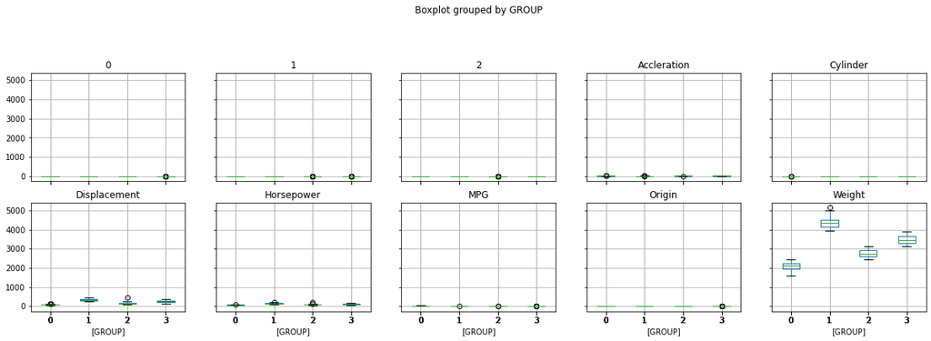

```python
final_USL_data.boxplot(by='GROUP', layout = (5,5),figsize=(20,15))
```

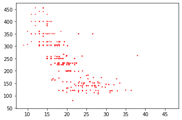

```python
plt.scatter(data=final_USL_data, x="MPG", y="Displacement", s="GROUP", c="red", alpha=0.9)
plt.show()
```

# Part 2

## DOMAIN: Automobile

## CONTEXT:

## The purpose is to classify a given silhouette as one of three types of vehicle, using a set of features extracted from the silhouette.The vehicle may be viewed from one of many different angles.

## DATA DESCRIPTION:

## The data contains features extracted from the silhouette of vehicles in different angles. Four "Corgie" model vehicles were used for the experiment: a double decker bus, Cheverolet van, Saab 9000 and an Opel Manta 400 cars. This particular combination of vehicles was chosen with the expectation that the bus, van and either one of the cars would be readily distinguishable, but it would be more difficult to distinguish between the cars.

## All the features are numeric i.e. geometric features extracted from the silhouette.

## PROJECT OBJECTIVE:

## Apply dimensionality reduction technique – PCA and train a model using principal components instead of training the model using just the raw data.

```python
import pandas as pd
import numpy as np
import matplotlib.pyplot as plt
%matplotlib inline
import seaborn as sns
sns.set(color_codes=True)
import warnings
warnings.filterwarnings('ignore')


from scipy.stats import zscore
from sklearn.decomposition import PCA
from sklearn.model_selection import train_test_split
from sklearn.svm import SVC
from sklearn.metrics import confusion_matrix, classification_report,accuracy_score,precision_recall_fscore_support
from sklearn import metrics
```

```python
vehicle = pd.read_csv('vehicle.csv')
vehicle.head(10)
```

|  | compactness | circularity | distance_circularity | radius_ratio | pr.axis_aspect_ratio | max.length_aspect_ratio | scatter_ratio | elongatedness | pr.axis_rectangularity | max.length_rectangularity | scaled_variance | scaled_variance.1 | scaled_radius_of_gyration | scaled_radius_of_gyration.1 | skewness_about | skewness_about.1 | skewness_about.2 | hollows_ratio | class |
| --- | --- | --- | --- | --- | --- | --- | --- | --- | --- | --- | --- | --- | --- | --- | --- | --- | --- | --- | --- |
| 0 | 95 | 48.0 | 83.0 | 178.0 | 72.0 | 10 | 162.0 | 42.0 | 20.0 | 159 | 176.0 | 379.0 | 184.0 | 70.0 | 6.0 | 16.0 | 187.0 | 197 | van |
| 1 | 91 | 41.0 | 84.0 | 141.0 | 57.0 | 9 | 149.0 | 45.0 | 19.0 | 143 | 170.0 | 330.0 | 158.0 | 72.0 | 9.0 | 14.0 | 189.0 | 199 | van |
| 2 | 104 | 50.0 | 106.0 | 209.0 | 66.0 | 10 | 207.0 | 32.0 | 23.0 | 158 | 223.0 | 635.0 | 220.0 | 73.0 | 14.0 | 9.0 | 188.0 | 196 | car |
| 3 | 93 | 41.0 | 82.0 | 159.0 | 63.0 | 9 | 144.0 | 46.0 | 19.0 | 143 | 160.0 | 309.0 | 127.0 | 63.0 | 6.0 | 10.0 | 199.0 | 207 | van |
| 4 | 85 | 44.0 | 70.0 | 205.0 | 103.0 | 52 | 149.0 | 45.0 | 19.0 | 144 | 241.0 | 325.0 | 188.0 | 127.0 | 9.0 | 11.0 | 180.0 | 183 | bus |
| 5 | 107 | NaN | 106.0 | 172.0 | 50.0 | 6 | 255.0 | 26.0 | 28.0 | 169 | 280.0 | 957.0 | 264.0 | 85.0 | 5.0 | 9.0 | 181.0 | 183 | bus |
| 6 | 97 | 43.0 | 73.0 | 173.0 | 65.0 | 6 | 153.0 | 42.0 | 19.0 | 143 | 176.0 | 361.0 | 172.0 | 66.0 | 13.0 | 1.0 | 200.0 | 204 | bus |
| 7 | 90 | 43.0 | 66.0 | 157.0 | 65.0 | 9 | 137.0 | 48.0 | 18.0 | 146 | 162.0 | 281.0 | 164.0 | 67.0 | 3.0 | 3.0 | 193.0 | 202 | van |
| 8 | 86 | 34.0 | 62.0 | 140.0 | 61.0 | 7 | 122.0 | 54.0 | 17.0 | 127 | 141.0 | 223.0 | 112.0 | 64.0 | 2.0 | 14.0 | 200.0 | 208 | van |
| 9 | 93 | 44.0 | 98.0 | NaN | 62.0 | 11 | 183.0 | 36.0 | 22.0 | 146 | 202.0 | 505.0 | 152.0 | 64.0 | 4.0 | 14.0 | 195.0 | 204 | car |

```python
vehicle.shape
```

```
(846, 19)
```

```python
vehicle.info()
```

```
<class 'pandas.core.frame.DataFrame'>
RangeIndex: 846 entries, 0 to 845
Data columns (total 19 columns):
 #   Column                       Non-Null Count  Dtype
---  ------                       --------------  -----
 0   compactness                  846 non-null    int64
 1   circularity                  841 non-null    float64
 2   distance_circularity         842 non-null    float64
 3   radius_ratio                 840 non-null    float64
 4   pr.axis_aspect_ratio         844 non-null    float64
 5   max.length_aspect_ratio      846 non-null    int64
 6   scatter_ratio                845 non-null    float64
 7   elongatedness                845 non-null    float64
 8   pr.axis_rectangularity       843 non-null    float64
 9   max.length_rectangularity    846 non-null    int64
 10  scaled_variance              843 non-null    float64
 11  scaled_variance.1            844 non-null    float64
 12  scaled_radius_of_gyration    844 non-null    float64
 13  scaled_radius_of_gyration.1  842 non-null    float64
 14  skewness_about               840 non-null    float64
 15  skewness_about.1             845 non-null    float64
 16  skewness_about.2             845 non-null    float64
 17  hollows_ratio                846 non-null    int64
 18  class                        846 non-null    object
dtypes: float64(14), int64(4), object(1)
memory usage: 125.7+ KB
```

```python
print('Duplicated rows: ', vehicle[vehicle.duplicated()].shape[0])
```

```
Duplicated rows:  0
```

```python
vehicle.isnull().sum()
```

```
compactness                    0
circularity                    5
distance_circularity           4
radius_ratio                   6
pr.axis_aspect_ratio           2
max.length_aspect_ratio        0
scatter_ratio                  1
elongatedness                  1
pr.axis_rectangularity         3
max.length_rectangularity      0
scaled_variance                3
scaled_variance.1              2
scaled_radius_of_gyration      2
scaled_radius_of_gyration.1    4
skewness_about                 6
skewness_about.1               1
skewness_about.2               1
hollows_ratio                  0
class                          0
dtype: int64
```